# Prevendo Demandas de Estoque com Base em Vendas

Luiz Fernando Mello

29/06/2021

# Preparando os dados para Análise Exploratória

## Setar local de trabalho

```r
setwd("C:/repos/Projeto02_PrevendoDemandaDeEstoqueComBaseEmVendas/Script")
```

## Carregar bibliotecas

```r
library(data.table)
library(dplyr)
```

```r
library(ggplot2)
library(corrplot)
```

## Carregar o dataset

```r
dados <- fread("../Datasets/train.csv", header = TRUE, sep = ",",
               encoding = "UTF-8")
```

## Split no dataset

```r
set.seed(357123)
indexSplit <- sample.int(nrow(dados), 600000)
vendas <- dados[indexSplit,]
```

## Remover variáveis que não vão ser utilizadas

```r
rm(dados, indexSplit)
```

## Visualizar os dados

```r
str(vendas)
```

```
## Classes 'data.table' and 'data.frame':   600000 obs. of  11 variables:
##  $ Semana           : int  7 5 4 3 9 8 3 6 9 3 ...
##  $ Agencia_ID       : int  2213 2242 1419 2016 1123 1531 1441 1215 1116 2071 ...
##  $ Canal_ID         : int  1 1 1 1 1 1 1 1 1 1 ...
##  $ Ruta_SAK         : int  2904 2805 1180 1297 1209 1113 4456 1021 1066 2132 ...
##  $ Cliente_ID       : int  800386 736561 92533 177985 409619 2303438 1830266 2417413 109864 510715 ...
##  $ Producto_ID      : int  31310 30551 43200 1109 1284 41843 43067 36318 2665 31310 ...
##  $ Venta_uni_hoy    : int  6 3 3 1 5 9 1 2 6 5 ...
##  $ Venta_hoy        : num  37.5 16.1 54.7 15 15.1 ...
##  $ Dev_uni_proxima  : int  0 0 0 0 0 0 0 0 0 0 ...
##  $ Dev_proxima      : num  0 0 0 0 0 0 0 0 0 0 ...
##  $ Demanda_uni_equil: int  6 3 3 1 5 9 1 2 6 5 ...
##  - attr(*, ".internal.selfref")=<externalptr>
```

## Verificar se existe valores NA

```r
any(is.na(vendas))
```

```
## [1] FALSE
```

## Renomear as variáveis do dataset

```r
novosNomes <- c("Semana", "Agencia_ID", "Canal_ID",
                "Rota_ID", "Cliente_ID", "Produto_ID",
                "Unidade_Vendida", "Peso_Vendido", "Unidade_Devolucao",
                "Peso_Devolucao", "Demanda_Estoque")
colnames(vendas) <- novosNomes
```

## Alterar tipo de dado das variáveis categóricas

```r
var.categoricas <- c("Semana", "Agencia_ID", "Canal_ID",
                     "Rota_ID", "Cliente_ID", "Produto_ID")

for(i in var.categoricas) {
  vendas[[i]] <- as.factor(vendas[[i]])
}
```

## Declarando vetor com variáveis numéricas

```r
var.numericas <- c(character(0))
for(i in colnames(vendas)) {
  if(is.numeric(vendas[[i]])) {
    var.numericas <- append(var.numericas, i)
  }
}
```

# Análise Exploratória das variáveis numéricas

## Medidas de tendência central

```r
for(i in var.numericas) {
  print(paste("Medidas de tendencia central da variável", i))
  print(summary(vendas[[i]]))
  cat("\n")
}
```

```
## [1] "Medidas de tendencia central da variável Unidade_Vendida"
##     Min.  1st Qu.   Median     Mean  3rd Qu.     Max.
##    0.000    2.000    3.000    7.288    7.000 3834.000
##
## [1] "Medidas de tendencia central da variável Peso_Vendido"
##     Min.  1st Qu.   Median     Mean  3rd Qu.     Max.
##     0.00    16.76    30.00    68.32    56.10 36806.40
##
## [1] "Medidas de tendencia central da variável Unidade_Devolucao"
##     Min.  1st Qu.   Median     Mean  3rd Qu.     Max.
##   0.0000   0.0000   0.0000   0.1274   0.0000 740.0000
##
## [1] "Medidas de tendencia central da variável Peso_Devolucao"
##     Min.  1st Qu.   Median     Mean  3rd Qu.     Max.
##    0.000    0.000    0.000    1.214    0.000 8442.000
##
## [1] "Medidas de tendencia central da variável Demanda_Estoque"
##    Min. 1st Qu.  Median    Mean 3rd Qu.    Max.
##     0.0     2.0     3.0     7.2     6.0  3834.0
```

## Medidas de dispersão

```r
for(i in var.numericas) {
  print(paste("Medidas de dispersão da variável", i))
  print(paste("Variância:", round(var(vendas[[i]]), 2)))
  print(paste("Desvio padrão:", round(sd(vendas[[i]]), 2)))
  cat("\n")
}
```

```
## [1] "Medidas de dispersão da variável Unidade_Vendida"
## [1] "Variância: 436.91"
## [1] "Desvio padrão: 20.9"
##
## [1] "Medidas de dispersão da variável Peso_Vendido"
## [1] "Variância: 82383.01"
## [1] "Desvio padrão: 287.02"
##
## [1] "Medidas de dispersão da variável Unidade_Devolucao"
## [1] "Variância: 5.49"
## [1] "Desvio padrão: 2.34"
##
## [1] "Medidas de dispersão da variável Peso_Devolucao"
## [1] "Variância: 458.68"
## [1] "Desvio padrão: 21.42"
##
## [1] "Medidas de dispersão da variável Demanda_Estoque"
## [1] "Variância: 428.68"
## [1] "Desvio padrão: 20.7"
```

## Histogramas

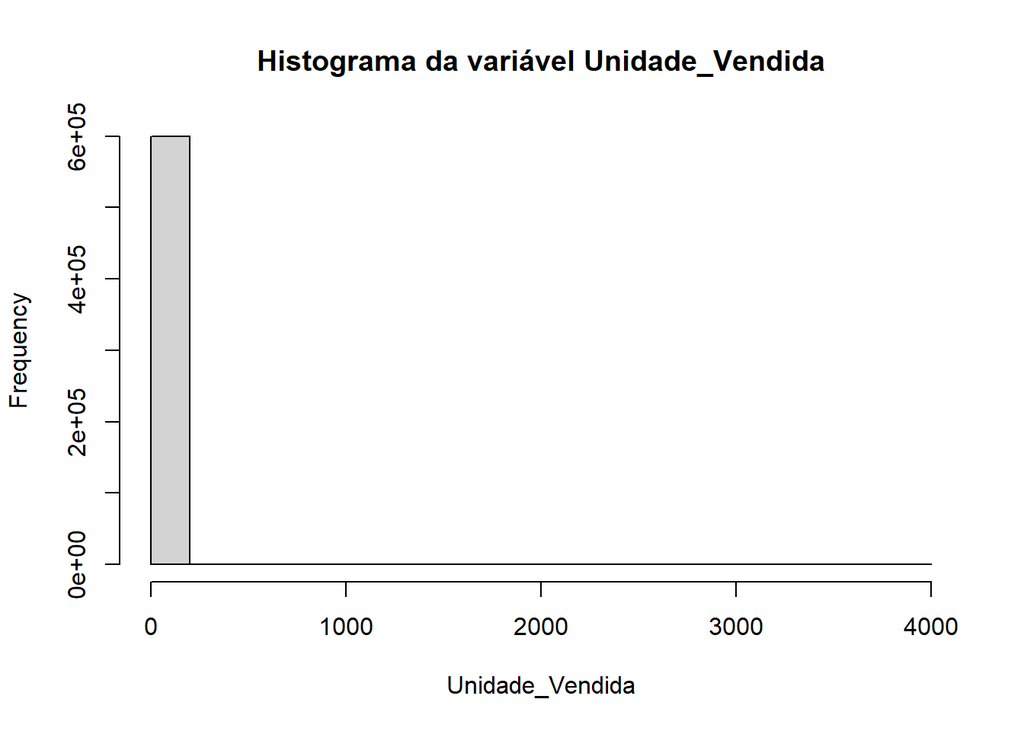

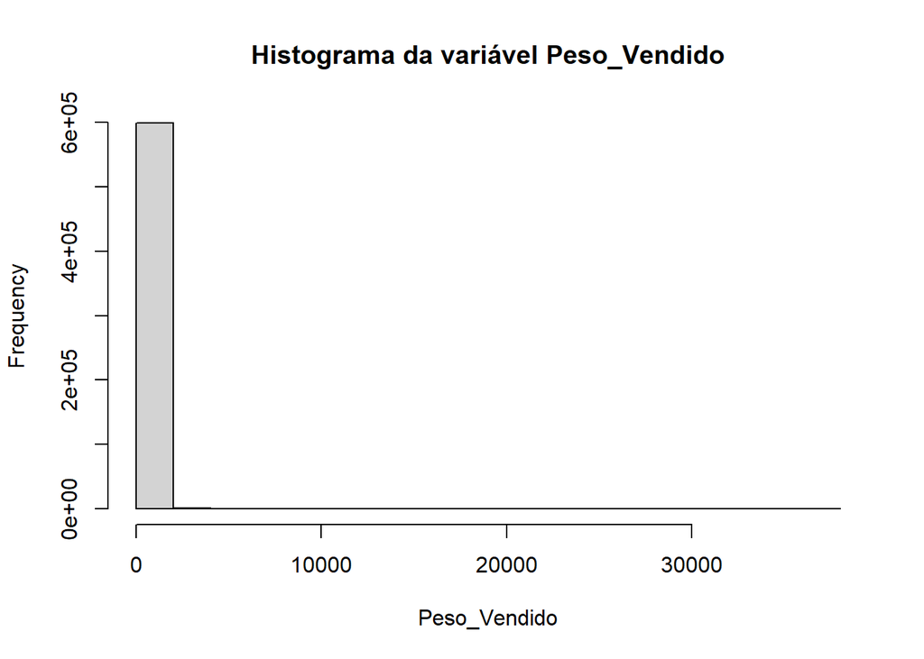

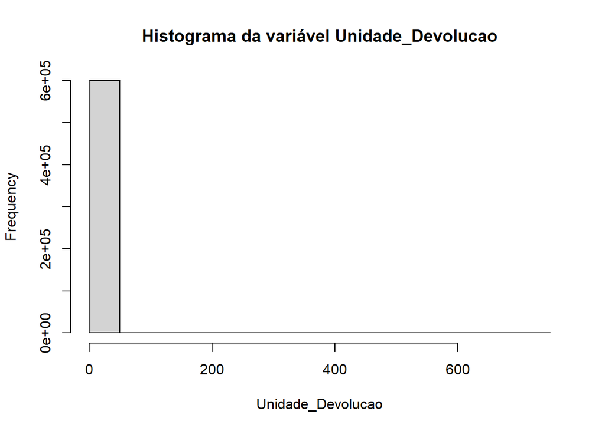

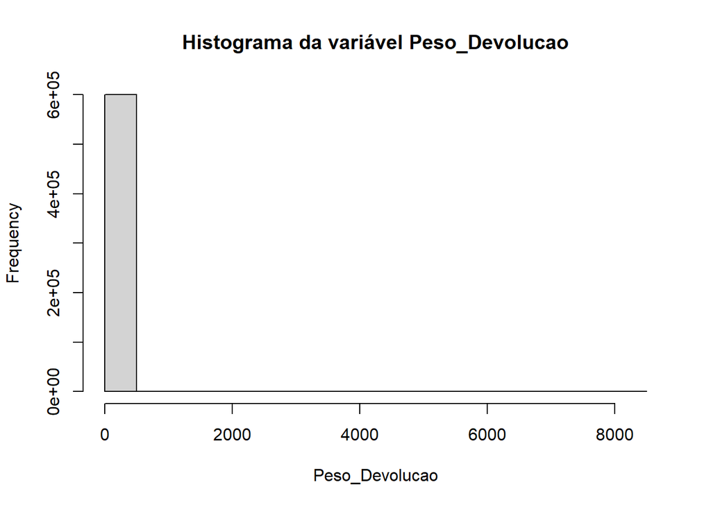

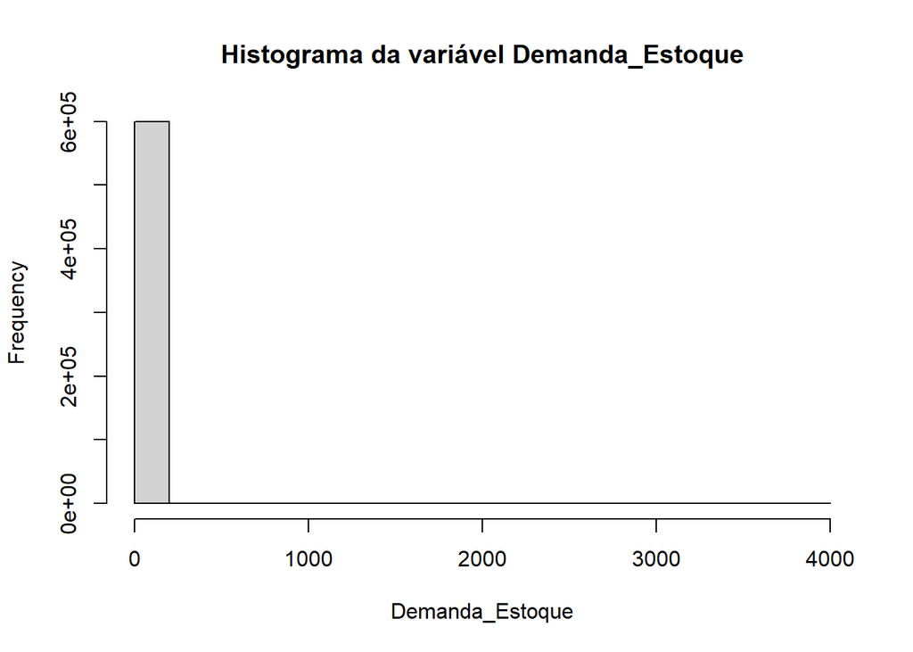

```r
for(i in var.numericas) {
  hist(vendas[[i]],
       main = paste("Histograma da variável", i),
       xlab = i)
}
```

##### Conclusão: Analisando as frequencias, as variáveis não estão em uma distribuição normal parece que temos muitos outliers, vamos verificar melhor com boxplot.

## Boxplots

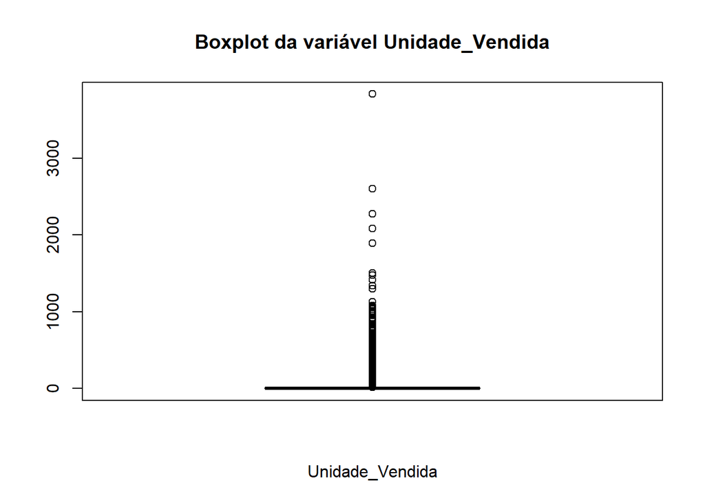

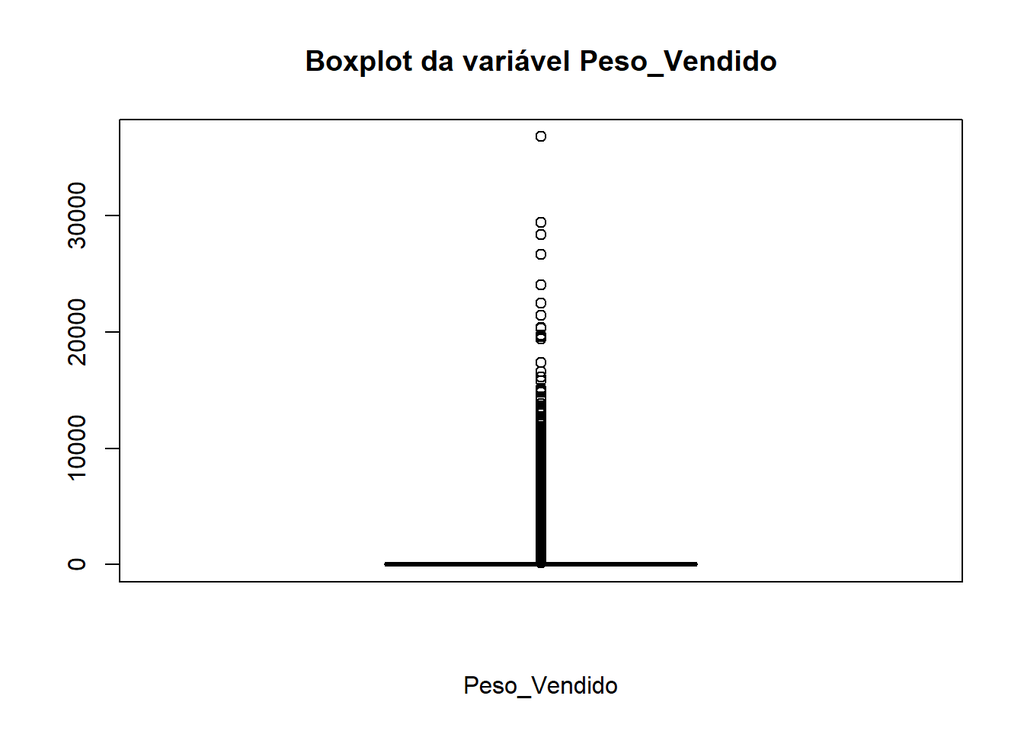

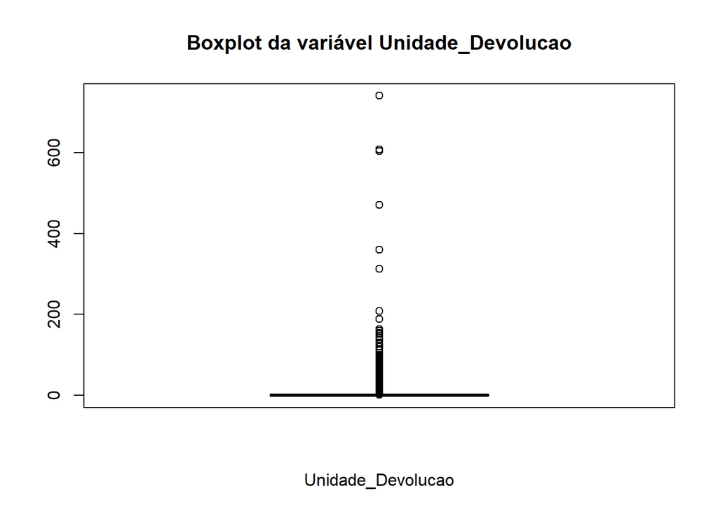

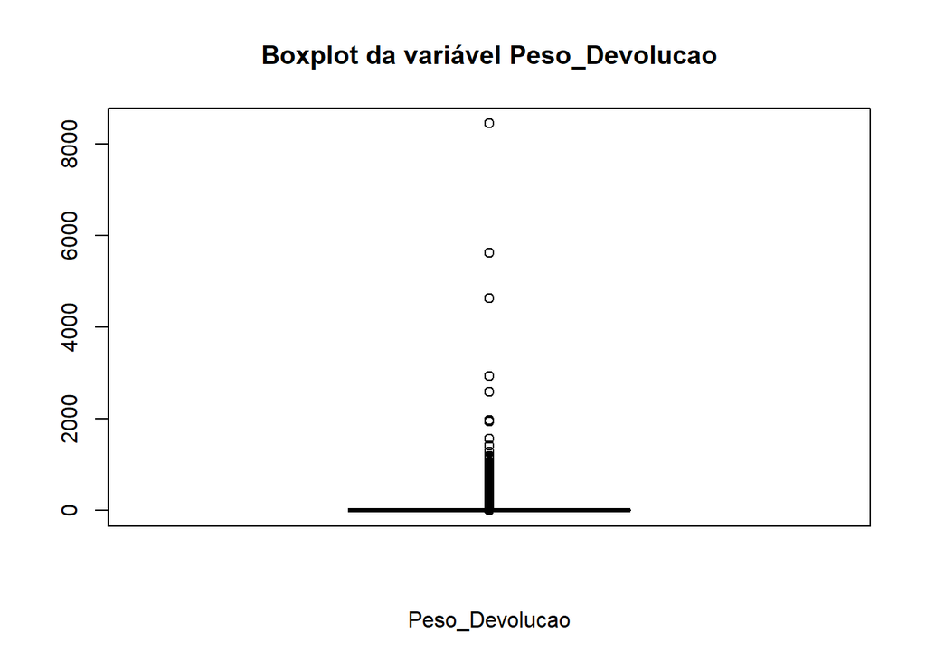

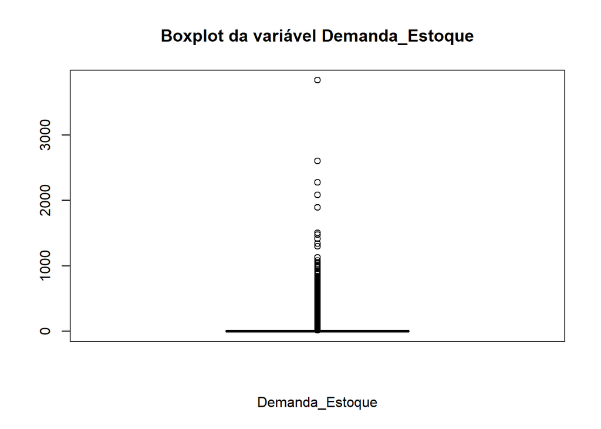

```r
for(i in var.numericas) {
  boxplot(vendas[[i]],
       main = paste("Boxplot da variável", i),
       xlab = i)
}
```

##### Conclusão: Muitos outliers em nossas variáveis.

## Análise de correlação (Plot de correlação das variáveis)

```
## Note: Using an external vector in selections is ambiguous.
## i Use `all_of(var.numericas)` instead of `var.numericas` to silence this message.
## i See <https://tidyselect.r-lib.org/reference/faq-external-vector.html>.
```

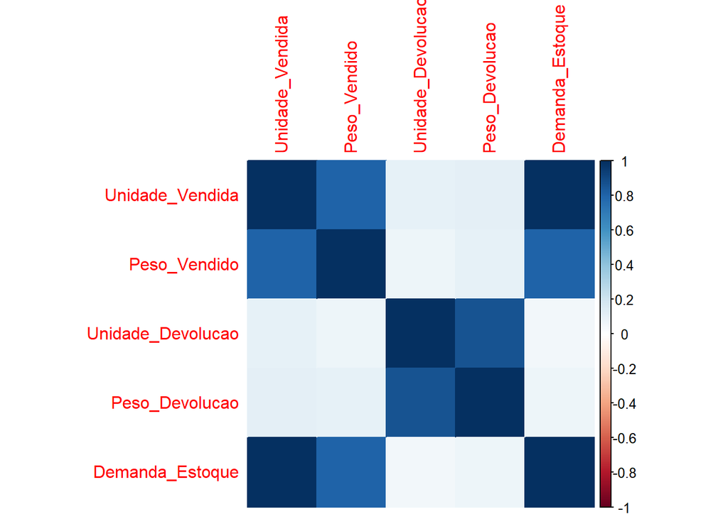

```r
corrplot(cor(select(vendas, var.numericas)), method = "color")
```

##### Conclusão: As variáveis que tem mais correlação com a variavel target (Demanda_Estoque) é Unidade_Vendida e Peso_Vendido

# Análisando os dados por semana

## Preparando os dados para realizar a análise

```r
vendas_semana <- vendas %>%
  group_by(Semana) %>%
  summarise(Unidade_Devolucao = sum(Unidade_Devolucao),
            Unidade_Vendida = sum(Unidade_Vendida),
            Peso_Vendido = sum(Peso_Vendido),
            Peso_Devolucao = sum(Peso_Devolucao),
            Demanda_Estoque = sum(Demanda_Estoque))
```

## Tabela de dados sumarizados por semana

```r
print(vendas_semana)
```

```
## # A tibble: 7 x 6
##   Semana Unidade_Devolucao Unidade_Vendida Peso_Vendido Peso_Devolucao
##   <fct>              <int>           <int>        <dbl>          <dbl>
## 1 3                  10075          636845     5997442.         99480.
## 2 4                  11025          640420     6023422.        109466.
## 3 5                   9779          628016     5814727.         95156.
## 4 6                  10470          604587     5598577.         99432.
## 5 7                  11863          620378     5756102.        111463.
## 6 8                  11535          629471     5981950.        108270.
## 7 9                  11688          612936     5818725.        105418.
## # ... with 1 more variable: Demanda_Estoque <int>
```

## Gráfico de cada variável numérica por semana

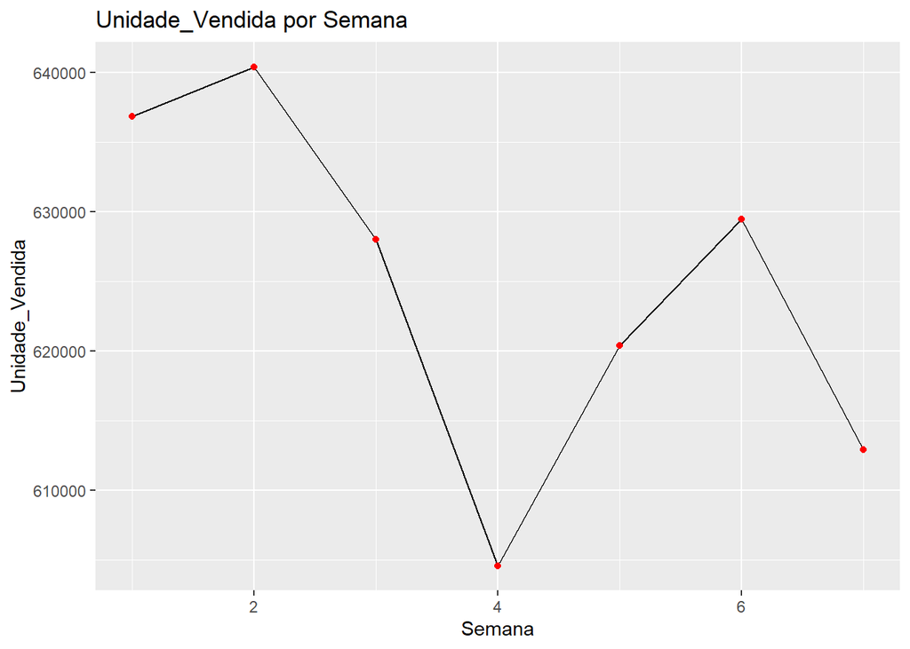

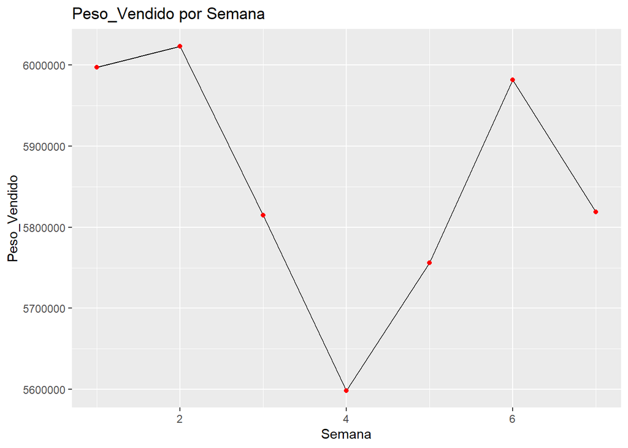

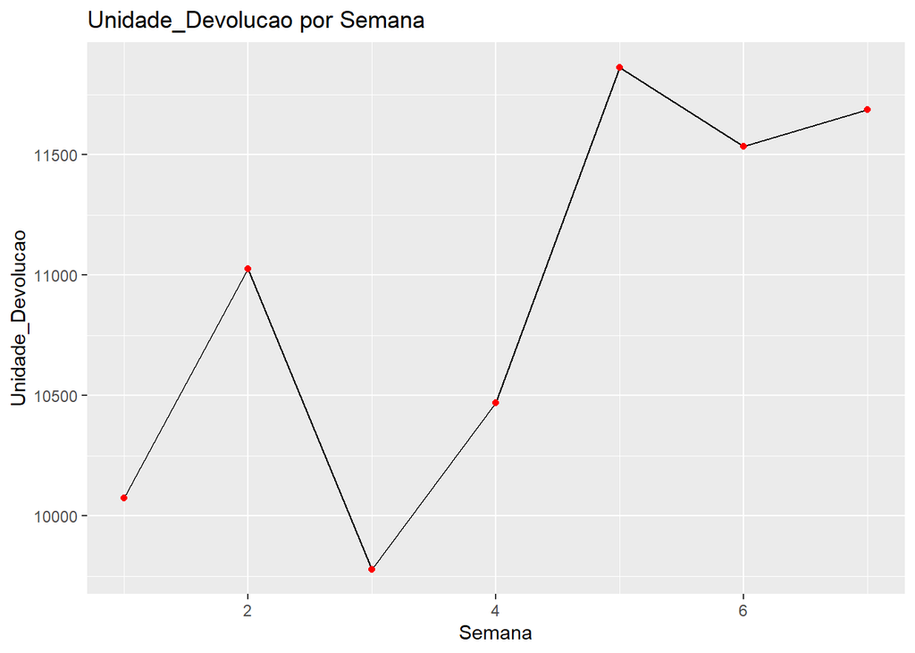

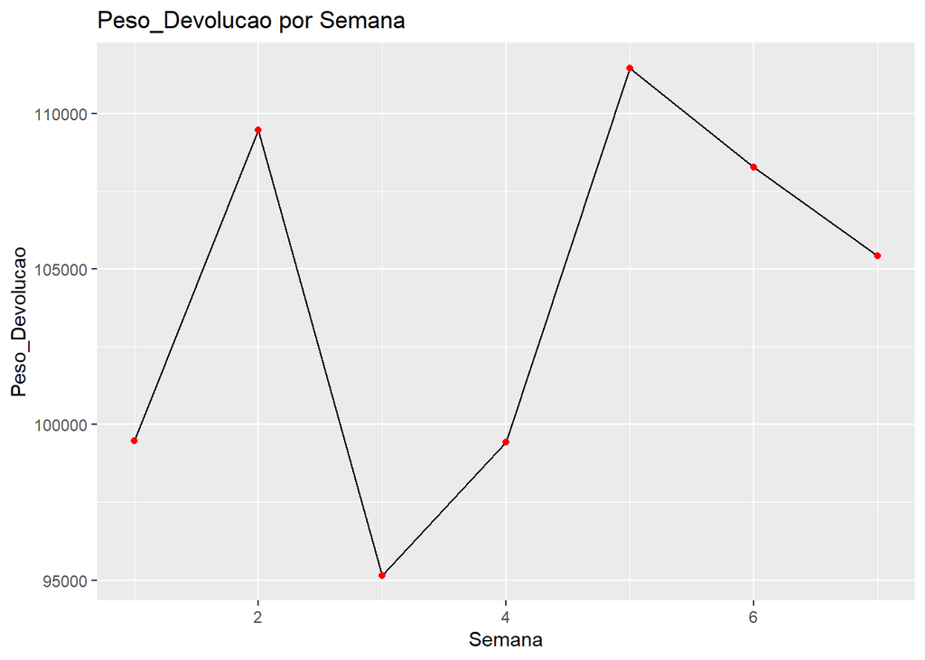

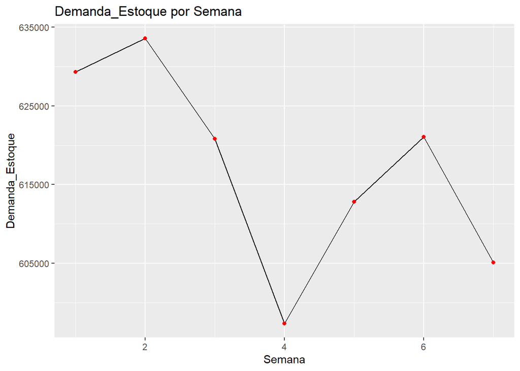

```r
for(i in var.numericas) {
    plot(ggplot(vendas_semana, aes(x = as.integer(Semana), y = .data[[i]])) +
      geom_line() +
      geom_point(color = "red") +
      ggtitle(paste(i, "por Semana")) +
      xlab("Semana"))
}
```

##### A semana com mais Unidades devolvidas é a semana 7

##### A semana com mais Pesos devolvidos é a semana 7

##### A semana com mais Demanda de estoque é a semana 4

# Análisando os dados por produto

## Preparando os dados para realizar a análise

```r
vendas_produto <- vendas %>%
  select(Produto_ID, Unidade_Vendida, Peso_Vendido,
         Unidade_Devolucao, Peso_Devolucao, Demanda_Estoque) %>%
  group_by(Produto_ID) %>%
  summarise(Unidade_Vendida = sum(Unidade_Vendida),
            Peso_Vendido = sum(Peso_Vendido),
            Unidade_Devolucao = sum(Unidade_Devolucao),
            Peso_Devolucao = sum(Peso_Devolucao),
            Demanda_Estoque = sum(Demanda_Estoque))
```

## Tabela de dados sumarizados por produto

```r
print(vendas_produto)
```

```
## # A tibble: 1,230 x 6
##    Produto_ID Unidade_Vendida Peso_Vendido Unidade_Devolucao Peso_Devolucao
##    <fct>                <int>        <dbl>             <int>          <dbl>
##  1 53                    1004       14357.                 0            0
##  2 72                    5918       21779.               118          437.
##  3 73                    6186      133075.               134         2864.
##  4 106                     80        1557.                 0            0
##  5 123                   1299       27700.                 2           42.7
##  6 131                    164        3149.                 0            0
##  7 132                    187        2738.                 0            0
##  8 134                     55        2640                  0            0
##  9 135                    229       11175.                 0            0
## 10 141                   1366       19046.                10          140.
## # ... with 1,220 more rows, and 1 more variable: Demanda_Estoque <int>
```

## Gráfico de cada variável numérica por produto

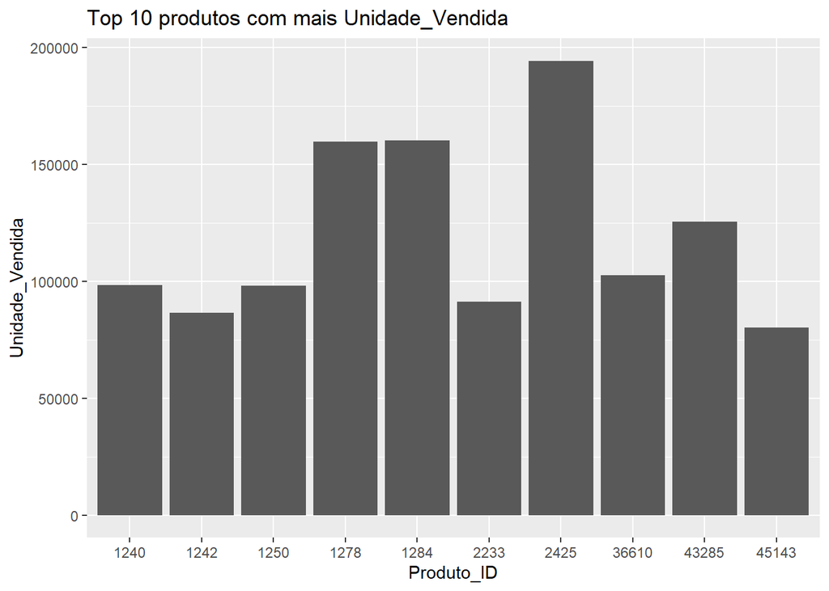

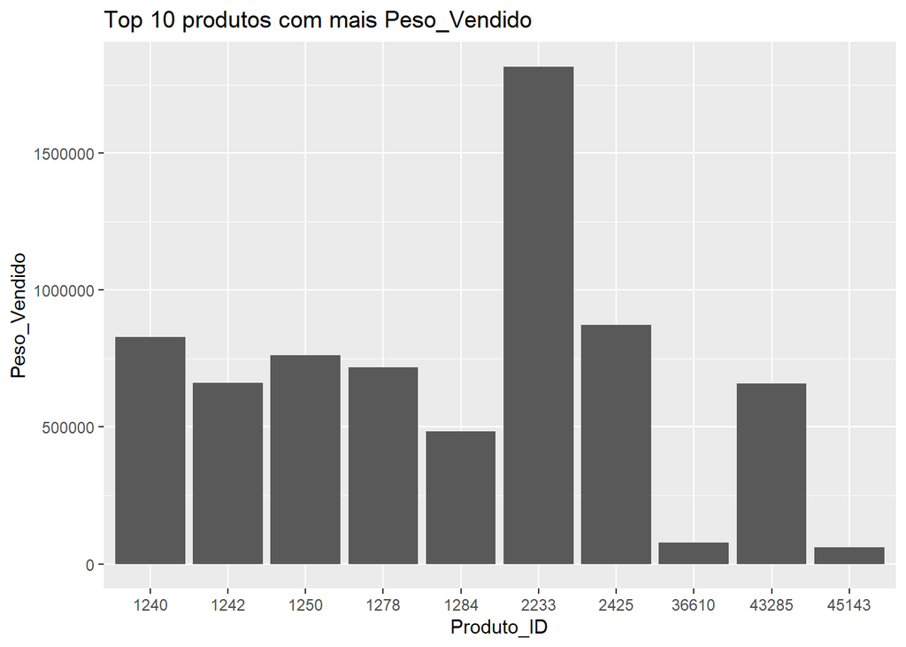

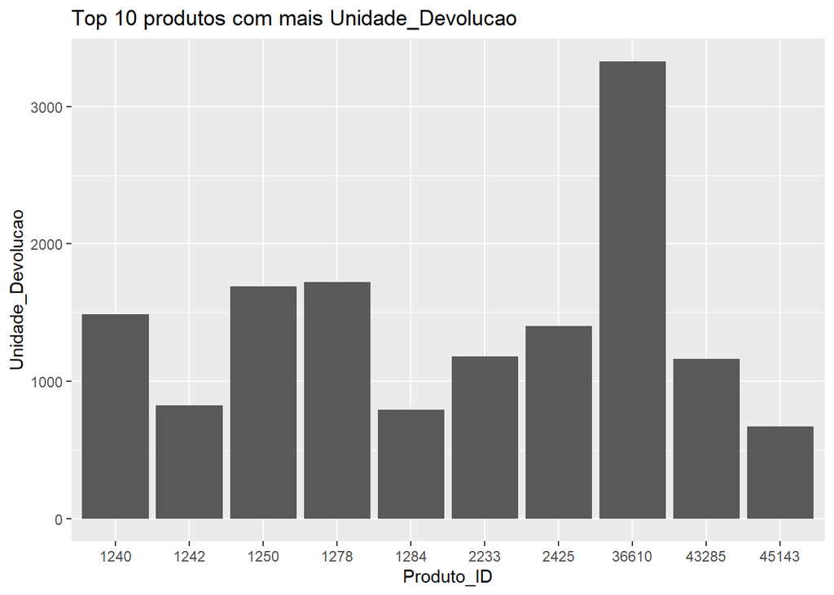

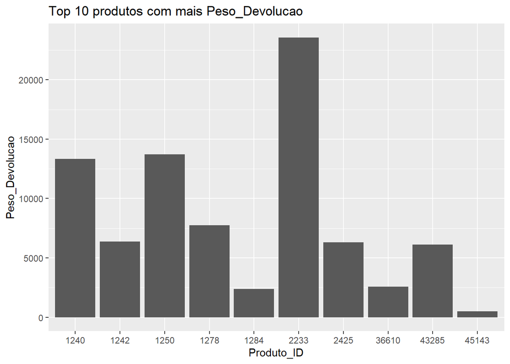

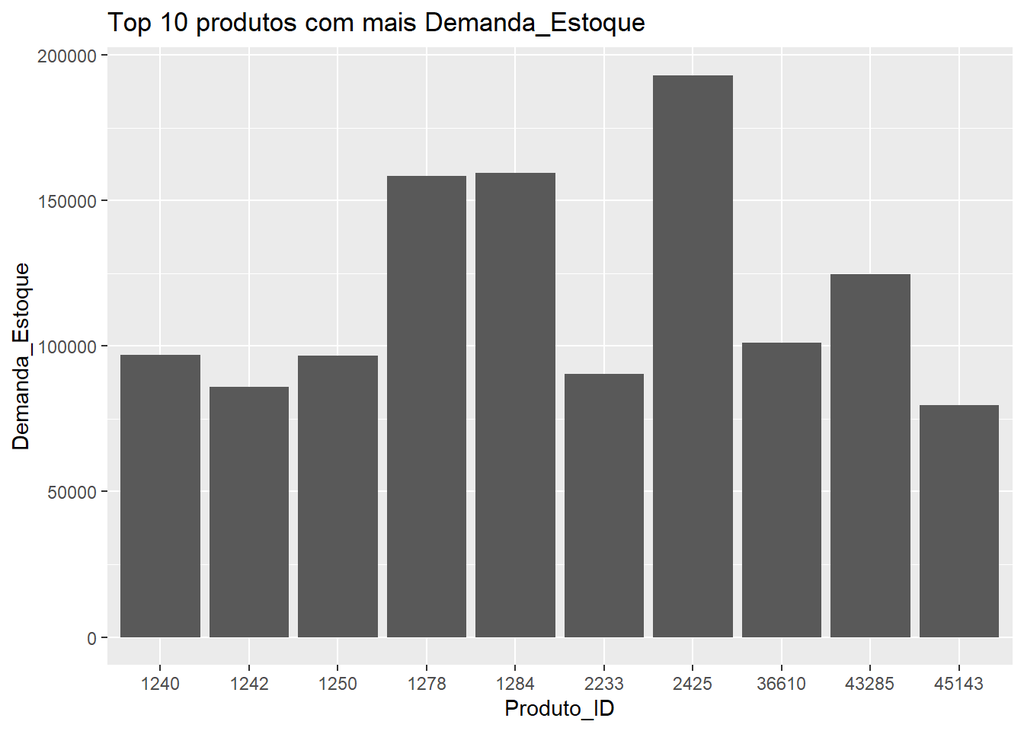

```r
for(i in var.numericas) {
  # Ordenar o dataframe em ordem decrescente com a variável que está sendo
  # iterada e pegar os 10 primeiros
  plot(ggplot(top_n(vendas_produto[order(-vendas_produto[[i]]),], 10),
         aes(Produto_ID, .data[[i]])) +
    geom_bar(stat = "identity") +
    ggtitle(paste("Top 10 produtos com mais", i)))
}
```

##### Conclusão:

##### Produto 2425 com mais unidades vendidas

##### Produto 2233 com mais peso vendido

##### Produto 36610 com mais unidades devolvidas

##### Produto 2233 com mais peso devolvido

##### Produto 2425 com mais demanda de estoque

# Análisando os dados por cliente

## Preparando os dados para realizar a análise

```r
vendas_cliente <- vendas %>%
  select(Cliente_ID, Unidade_Vendida, Peso_Vendido,
         Unidade_Devolucao, Peso_Devolucao, Demanda_Estoque) %>%
  group_by(Cliente_ID) %>%
  summarise(Unidade_Vendida = sum(Unidade_Vendida),
            Peso_Vendido = sum(Peso_Vendido),
            Unidade_Devolucao = sum(Unidade_Devolucao),
            Peso_Devolucao = sum(Peso_Devolucao),
            Demanda_Estoque = sum(Demanda_Estoque))
```

## Tabela de dados sumarizados por cliente

```r
print(vendas_cliente)
```

```
## # A tibble: 350,996 x 6
##    Cliente_ID Unidade_Vendida Peso_Vendido Unidade_Devolucao Peso_Devolucao
##    <fct>                <int>        <dbl>             <int>          <dbl>
##  1 26                      81       1579.                  0              0
##  2 60                     782      32397.                  0              0
##  3 65                     515       8091.                  0              0
##  4 105                    134       2306.                  0              0
##  5 106                     23        549.                  0              0
##  6 107                     97       1597.                  0              0
##  7 772                      3         29.5                 0              0
##  8 786                      1         11.5                 0              0
##  9 795                      2          9                   0              0
## 10 797                      3         20.3                 0              0
## # ... with 350,986 more rows, and 1 more variable: Demanda_Estoque <int>
```

## Gráfico de cada variável numérica por cliente

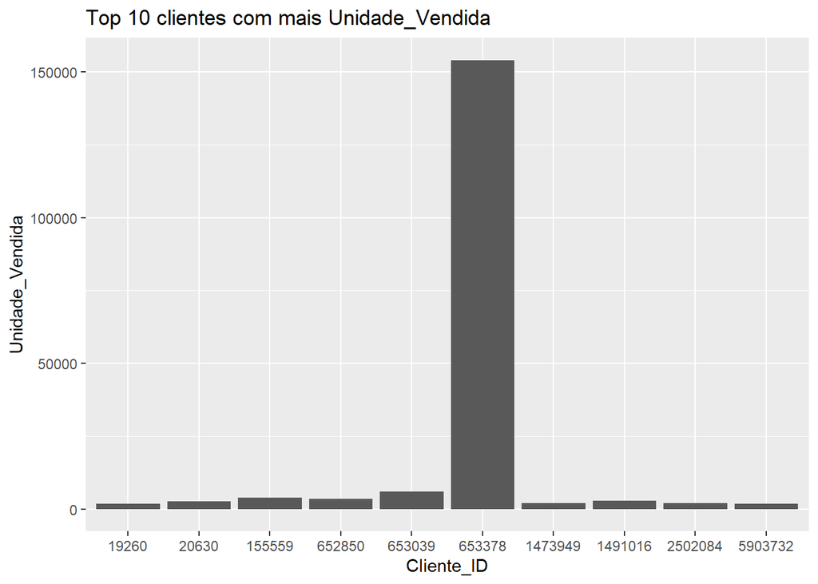

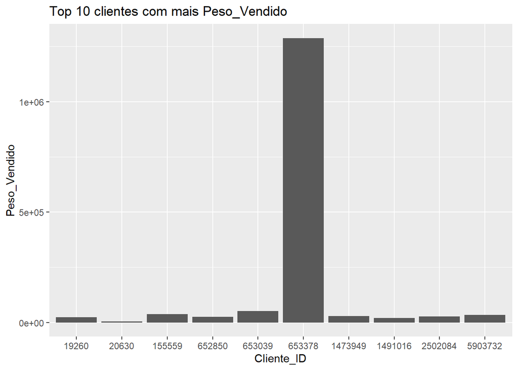

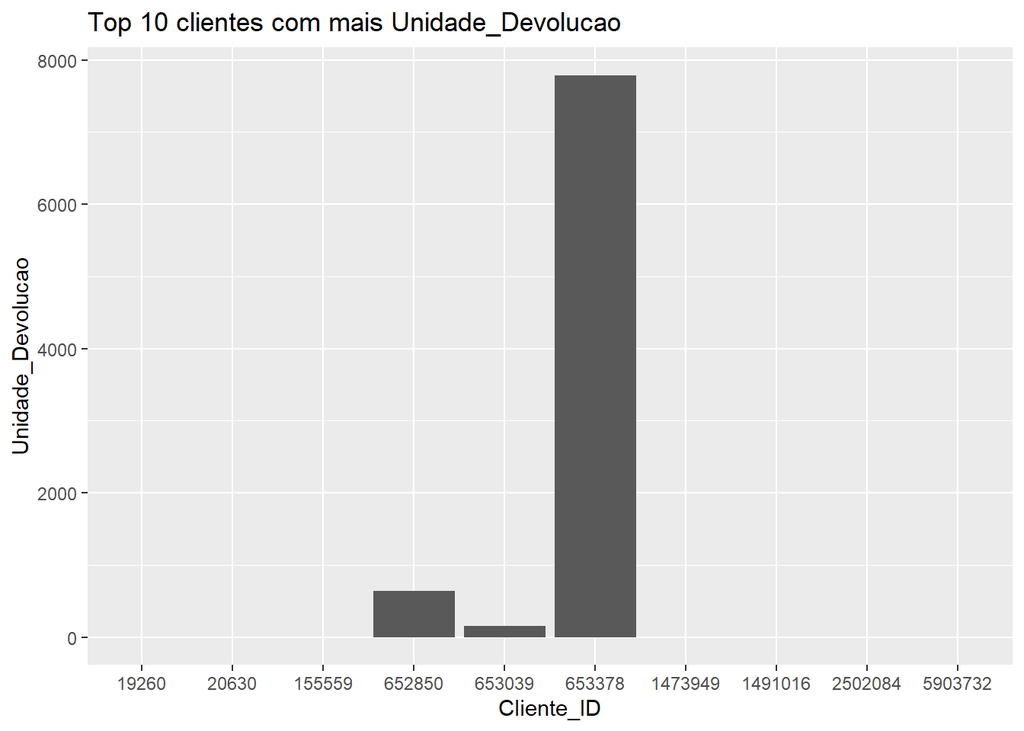

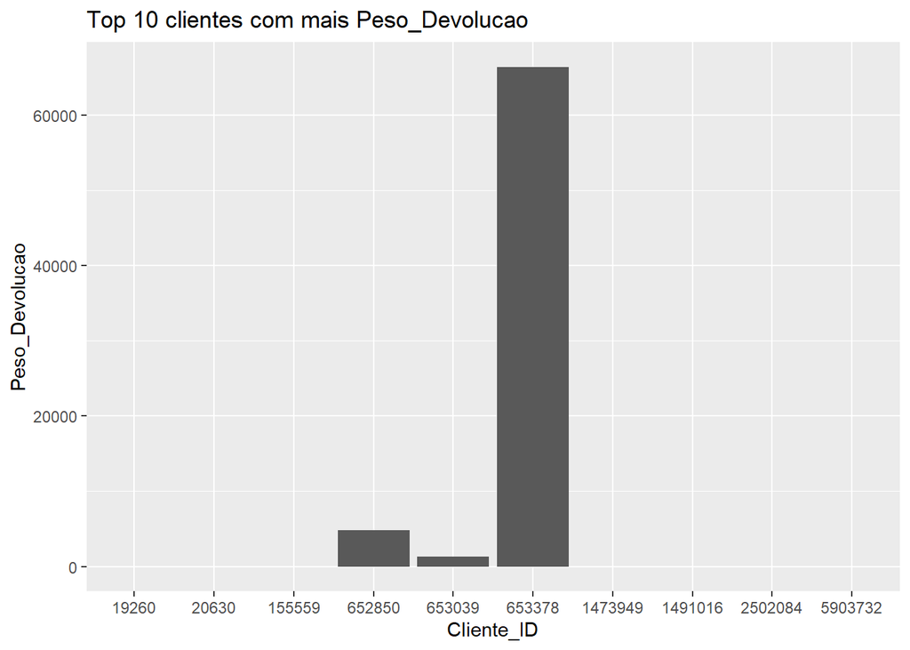

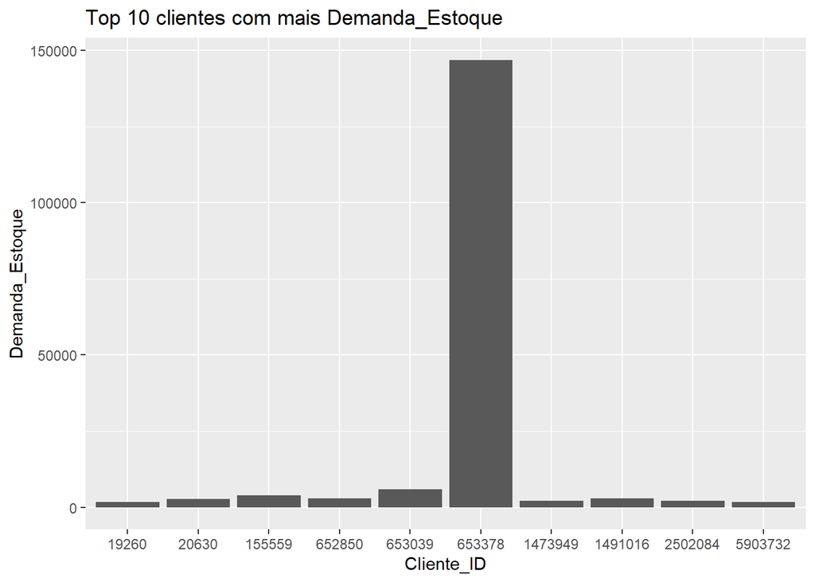

```r
for(i in var.numericas) {
  # Ordenar o dataframe em ordem decrescente com a variável que está sendo
  # iterada e pegar os 10 primeiros
  plot(ggplot(top_n(vendas_cliente[order(-vendas_cliente[[i]]),], 10),
              aes(Cliente_ID, .data[[i]])) +
         geom_bar(stat = "identity") +
         ggtitle(paste("Top 10 clientes com mais", i)))
}
```

##### Conclusão: 653378 é o cliente que mais comprou e devolveu produtos.

## Remover variáveis que foram declaradas para fazer as análises

```r
rm(vendas_cliente, vendas_produto, vendas_semana)
```

# Manipulação de dados

## Remover valores outliers das variáveis numéricas

```r
for(i in var.numericas) {
  maiorOutlier <- mean(vendas[[i]]) + (sd(vendas[[i]]) * 2)
  menorOutlier <- mean(vendas[[i]]) - (sd(vendas[[i]]) * 2)
  vendas[[i]][vendas[[i]] < menorOutlier] <- NA
  vendas[[i]][vendas[[i]] > maiorOutlier] <- NA
}

vendas <- na.omit(vendas)
```

## Transformar variáveis categóricas para numericas novamente, Motivo: Modelo fica muito pesado com variáveis fatores

```r
for(i in var.categoricas) {
  vendas[[i]] <- as.integer(vendas[[i]])
}
```

## Dividir os dados de treino e de teste

```r
indexTest <- sample.int(nrow(vendas), 100000)
dados.test <- vendas[indexTest,]
dados.train <- vendas[-indexTest,]
rm(vendas)
```

# Feature selection

## Carregar bibliotecas

```r
library(caret)
library(randomForest)
```

## Seleção de variáveis v1

```r
selecao_variaveis_v1 <- lm(Demanda_Estoque ~ .,
                        data = dados.train)

varImp(selecao_variaveis_v1)
```

```
##                        Overall
## Semana            9.910923e-01
## Agencia_ID        2.496298e+00
## Canal_ID          3.362791e+00
## Rota_ID           3.951107e+00
## Cliente_ID        2.321354e+00
## Produto_ID        2.519777e+00
## Unidade_Vendida   3.165737e+04
## Peso_Vendido      7.528509e+00
## Unidade_Devolucao 5.478647e+02
## Peso_Devolucao    8.236703e+01
```

#### Conclusão: Variáveis mais relevantes: Canal_ID, Rota_ID, Produto_ID, Unidade_Vendida, Peso_Vendido, Unidade_Devolucao e Peso_Devolucao

## Seleção de variáveis v2

```r
selecao_variaveis_v2 <- lm(Demanda_Estoque ~ Canal_ID
                           + Rota_ID
                           + Produto_ID
                           + Unidade_Vendida
                           + Peso_Vendido
                           + Unidade_Devolucao
                           + Peso_Devolucao,
                           data = dados.train)

varImp(selecao_variaveis_v2)
```

```
##                        Overall
## Canal_ID              3.228672
## Rota_ID               3.734198
## Produto_ID            2.511341
## Unidade_Vendida   31657.688638
## Peso_Vendido          7.409424
## Unidade_Devolucao   547.891591
## Peso_Devolucao       82.355612
```

#### Conclusão: Variáveis mais relevantes: Canal_ID, Rota_ID, Unidade_Vendida, Peso_Vendido, Unidade_Devolucao e Peso_Devolucao

# Construção do modelo preditivo

## Construir o modelo v1

```r
modelo_v1 <- train(Demanda_Estoque ~ Canal_ID
                   + Rota_ID
                   + Unidade_Vendida
                   + Peso_Vendido
                   + Unidade_Devolucao
                   + Peso_Devolucao,
                   data = dados.train, method = "lm",
                   preProcess = c("center", "scale"))
```

# Avaliação do modelo preditivo

## Visualizar o modelo

```r
summary(modelo_v1)
```

```
##
## Call:
## lm(formula = .outcome ~ ., data = dat)
##
## Residuals:
##      Min       1Q   Median       3Q      Max
## -1.23285 -0.00097  0.00010  0.00203  3.14947
##
## Coefficients:
##                     Estimate Std. Error   t value Pr(>|t|)
## (Intercept)        5.5528944  0.0001505 36893.194  < 2e-16 ***
## Canal_ID           0.0005011  0.0001686     2.973  0.00295 **
## Rota_ID            0.0007933  0.0001664     4.768 1.86e-06 ***
## Unidade_Vendida    6.7386201  0.0002118 31818.030  < 2e-16 ***
## Peso_Vendido      -0.0016407  0.0002142    -7.661 1.85e-14 ***
## Unidade_Devolucao -0.1965012  0.0003586  -548.002  < 2e-16 ***
## Peso_Devolucao    -0.0295853  0.0003589   -82.435  < 2e-16 ***
## ---
## Signif. codes:  0 '***' 0.001 '**' 0.01 '*' 0.05 '.' 0.1 ' ' 1
##
## Residual standard error: 0.105 on 486207 degrees of freedom
## Multiple R-squared:  0.9998, Adjusted R-squared:  0.9998
## F-statistic: 3.353e+08 on 6 and 486207 DF,  p-value: < 2.2e-16
```

## Resíduos do modelo preditivo

```r
residuos <- residuals(modelo_v1)
summary(residuos)
```

```
##       Min.    1st Qu.     Median       Mean    3rd Qu.       Max.
## -1.2328509 -0.0009650  0.0000958  0.0000000  0.0020274  3.1494686
```

#### Conclusão: Mediana do resíduo próximo de zero, ou seja, o modelo aprendeu uma boa relação com os dados

## Avaliando modelo com dados de teste

```r
previsoes <- predict(modelo_v1,
                     dados.test[,c("Canal_ID", "Rota_ID", "Unidade_Vendida",
                                   "Peso_Vendido", "Unidade_Devolucao",
                                   "Peso_Devolucao")])
```

## Criar datatable com resultados para calcular os rediduos

```r
data.resultados <- data.frame(real = dados.test$Demanda_Estoque,
                              previsoes = round(previsoes,0))
```

## Remover os valores negativos das previsoes

```r
data.resultados$previsoes <- sapply(data.resultados$previsoes,
                                    function(x) ifelse(x < 0, 0, x))
```

## Calcular os residuos das previsoes

```r
data.resultados <- data.resultados %>%
  mutate(residuo = previsoes - real)
```

## Visualizar residuos das previsoes com dados de teste

```r
summary(data.resultados$residuo)
```

```
##    Min. 1st Qu.  Median    Mean 3rd Qu.    Max.
## 0.00000 0.00000 0.00000 0.00313 0.00000 1.00000
```

#### Conclusão: Modelo preditivo aprendeu muito bem com os dados e está apto para realizar previsões com novos dados